# Aurora Rockfish

*Sebastes aurora*

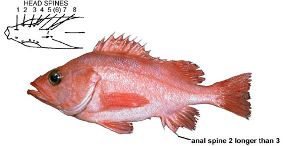

**Body color:** Uniform creamy light-red or pink.

**Peritoneum color:** dark to light w/ spots **Shape between eyes:** convex to concave

**Counts:** D:XIII,12-13, Ar:5-7, P1:17-19, GR:24-28, LLp:27-31, LLs:41-50,V:26

**Occurence:** British Columbia - Southern California

**Depth:** 81-893 meters **Size:** 41 cm **Species code:** 30090

**Similar species:**

- *Splitnose rockfish* - head spine count differs; knobs bordering notch in upper jaw prominent; gill rakers 32-37 (24-28 in Aurora RF); lateral line pores 32-43 (27-31 in Aurora RF); spines on lower margin of operculum typically present (typically absent in Aurora RF)
- *Stripetail rockfish* - head spine count differs; body yellow-pink w/ green; dorsal blotches present; no notch in upper jaw; spines on lower margin of operculum typically present (typically absent in Aurora RF)
- *Rougheye rockfish* - 2-8 spines below eye; body red w/ black; gill rakers 29-35 (24-28 in Aurora RF)
- *Shortraker rockfish* - anal spine 2 shorter than 3; notch in upper jaw absent

Back to Group

**Corrections:** If you see mistakes or want to suggest changes, please create an [issue](https://github.com/zoyafuso-NOAA/RACE_Survey_App/issues) on the source repository or

*reach out to Liz Dawson (Liz.Dawson AT noaa.gov).*